# Números enteros

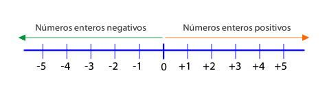

Números enteros representados en la recta numérica

### 1. Números enteros y como se ordenan

Los **números enteros** son los números positivos, los negativos y el cero. Mira esta [explicación](https://www.youtube.com/watch?v=5HE66809NYI).

Se usan para representar situaciones como:

- temperaturas bajo cero,
- pisos subterráneos,
- deudas y ganancias,
- alturas y profundidades.

Los números enteros tienen un orden.

- Un número ubicado más a la derecha es **mayor**.
- Un número ubicado más a la izquierda es **menor**.

Mira esta [explicación](https://www.youtube.com/watch?v=-lfIwmnptZ8).

Ejemplos:

- $5 > 2$
- $1 > -4$
- $-7 < 3$

**Regla importante:** Entre números negativos: *el que está **más cerca del cero** es el mayor.

**Ejercicios**

1. Ordena de menor a mayor:
- **a)** 3, -2, 0, -7, 5
- **b)** -10, -1, 4, 2, -3
2. Ordena de mayor a menor
- **a)** -12, -4, 0, 1, 2
- **b)** -1, -34, -5, 0

### 2. Valor absoluto o distancia de un número al cero

Observa en este [video](https://www.youtube.com/watch?v=CINR4osZFoU) como el valor absoluto de un número es igual a la distancia de ese número al “cero” en la recta numérica.

**Ejercicios:**

Resolver el valor absoluto en cada caso:

1. |3| = 3 (Ejemplo)
2. |-24|
3. |-2478|
4. |345|
5. |-634|

### 3. Distancia entre dos números enteros

Vamos a encontrar la distancia entre dos números enteros, es decir la longitud del segmento que une ambos números, operando con valores absolutos (distancia al cero).

Ejemplo 1:

¿Cuál es la distancia entre -2 y 2?

- Primero sacamos ambos valores absolutos
- Para encontrar la distancia entre ambos sumamos o restamos los valores absolutos según corresponda, en este caso, como ves en la figura es la suma.

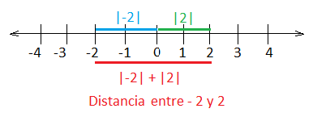

Ejemplo 2:

¿Cuál es la distancia entre -1 y -4?

Fijate en la figura que aquí la distancia es la resta por que así obtenemos la longitud del segmento que une ambos números.

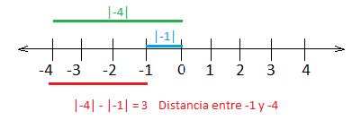

**Ejercicios:**

1. ¿Cual es la distancia entre -3 y 4?
2. ¿Cuál es la distancia entre -8 y -2?
3. ¿Cuál es la distancia entre 18 y -4?

### 4. Ejercicios adicionales Alternancia 3

(Todo lo anterior lo vimos en clase)

Los números enteros tienen muchas aplicaciones en la vida real, aquí verás solo algunas. Repasa el pto. 3 si lo necesitas:

1. ¿Cuál es la distancia entre 23 y -13? (ver pto. 3)
2. ¿Cuál es la distancia entre -500 y -250?
3. Un ascensor subió del subsuelo -2 al piso 9. ¿Cuántos pisos subió? ¿La respuesta es la distancia entre -2 y 9 (pto.3)?
4. Veladero es una mina de oro en San Juan que está en la cordillera de los Andes. Un empleado de la mina tomó el colectivo en la ciudad de San Juan donde hacía una temperatura de 8 grados. Al cabo de unas 6 horas llega a la mina y alli hace -18 grados. Es decir 18 grados bajo cero. ¿A qué amplitud de temperatura tuvo sometido el empleado ese día? (La amplitud es la distancia entre las temperaturas extremas)
5. Problema más difícil (no es obligatorio pero es conveniente que lo intentes como un desafío). **Viaje de exploración científica:** Para estudiar el clima y la geología, un equipo de científicos utiliza un dron diseñado para soportar temperaturas extremas y medir altitudes. El dron despega desde una estación meteorológica base situada a una altitud de **$150\text{ metros}$ sobre el nivel del mar**, donde el termómetro marca **$12^\circ\text{C}$**.
- **a)** **El primer vuelo:** El dron sube en línea recta hasta alcanzar una zona de nubes a una altitud de **$850\text{ metros}$**. Allí, la temperatura desciende drásticamente hasta los **$-13^\circ\text{C}$**.
  - ¿Cuántos metros ascendió el dron desde la estación base?
  - ¿Cuál fue la amplitud térmica (distancia entre temperaturas) que experimentó el dron en este primer trayecto?
- **b)** **La misión en la fosa:** Después, el dron desciende en picada para analizar una fosa geológica profunda que está a **$-230\text{ metros}$** (es decir, $230\text{ metros}$ bajo el nivel del mar). En el fondo de la fosa, la temperatura es de **$-4^\circ\text{C}$**.
  - ¿Cuántos metros recorrió el dron en total **solamente durante este descenso** (desde la zona de nubes a $850\text{ m}$ hasta el fondo de la fosa a $-230\text{ m}$)?
  - ¿Qué distancia hay entre la temperatura de la fosa ($-4^\circ\text{C}$) y la de las nubes ($-13^\circ\text{C}$)?
- **c)** **El análisis final:** Compara las amplitudes térmicas de las dos zonas respecto a la estación base: ¿Qué temperatura está más alejada (a mayor distancia) de la temperatura inicial de la estación base ($12^\circ\text{C}$): la de las nubes ($-13^\circ\text{C}$) o la de la fosa ($-4^\circ\text{C}$)? ¿Cuál es la diferencia entre esas dos distancias?

#### Autocorrección

El objetivo es aprender también de los errores y mejorar. Por esto una vez que los resuelvas activa esta sección para ver las respuestas, y autocorregirte como hacemos en clase:

- Si está bien: Un tilde **✓**
- Si está mal: Lo corriges y luego lo marcas con dos tildes **✓✓**

Los ejercicios del 1 al 4 son los que deben presentarse autocorregidos.

**Clic aquí** para ver las respuestas de esta sección**

1. **36** (porque |23| + |-13| = 23 + 13 = 36).
2. **250** (porque |-500| - |-250)| = 500 - 250).
3. **11** (subió 11 pisos y es lo mismo que la distancia entre -2 y 9)
4. Se corrige en clase.